# **ExtraaLearn Project**

## **Model Performance Visualization**

In this section, we will visualize the performance of the different machine learning models we built to predict lead conversion. This will help us compare their effectiveness and identify the best-performing model based on key evaluation metrics.

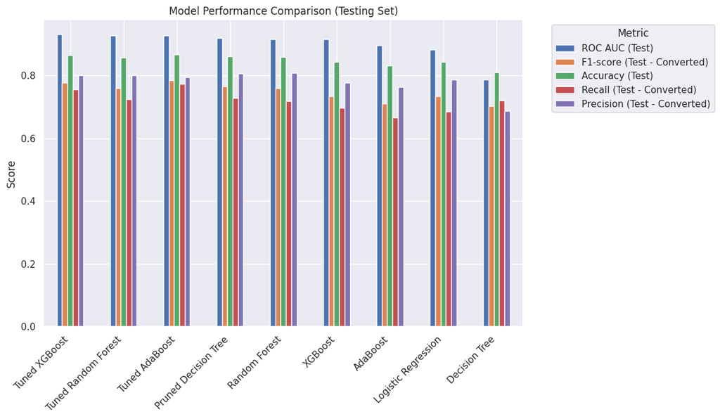

```python
# Select key performance metrics for visualization from the sorted model results DataFrame
metrics_to_visualize = ['ROC AUC (Test)', 'F1-score (Test - Converted)', 'Accuracy (Test)', 'Recall (Test - Converted)', 'Precision (Test - Converted)']

# Create a bar plot to compare the models based on the selected metrics
results_df_sorted[metrics_to_visualize].plot(kind='bar', figsize=(12, 7))

plt.title('Model Performance Comparison (Testing Set)')
plt.ylabel('Score')
plt.xticks(rotation=45, ha='right')
plt.legend(title='Metric', bbox_to_anchor=(1.05, 1), loc='upper left')
plt.tight_layout()
plt.show()
```

#### **Discussion on Evaluation Metrics**

In this project, we are using several key evaluation metrics to assess the performance of our classification models, particularly focusing on their ability to predict lead conversion (`status=1`). It is important to understand why these metrics are relevant in the context of this problem:

- **Accuracy:** Overall proportion of correctly classified instances. While a useful general metric, it can be misleading in imbalanced datasets (like ours, where non-converted leads are more numerous) as a model that predicts the majority class for all instances can still achieve high accuracy.
- **Precision (for Converted Class):** Out of all the leads the model *predicted* would convert, what proportion actually converted? High precision is important if the cost of wrongly predicting a non-converted lead as converted (false positive) is high (e.g., wasted sales resources).
- **Recall (for Converted Class):** Out of all the leads that *actually* converted, what proportion did the model correctly identify? High recall is important if the cost of missing a converted lead (false negative) is high (e.g., lost revenue opportunity).
- **F1-score (for Converted Class):** The harmonic mean of Precision and Recall. It provides a single score that balances both metrics, which is particularly useful in imbalanced datasets.
- **ROC AUC (Receiver Operating Characteristic Area Under the Curve):** Measures the model's ability to discriminate between the positive and negative classes across all possible classification thresholds. A higher ROC AUC indicates better overall discrimination power, regardless of the chosen threshold. This is a robust metric for evaluating classifiers on imbalanced data.
- **Precision-Recall Curve:** Plots Precision against Recall at various thresholds. This curve provides a visual trade-off between these two metrics and is often more informative than the ROC curve for imbalanced datasets when the focus is on the performance of the positive class.
- **Confusion Matrix:** A table showing the counts of True Positives (correctly predicted converted), True Negatives (correctly predicted non-converted), False Positives (non-converted predicted as converted), and False Negatives (converted predicted as non-converted). This provides a detailed breakdown of where the model is making errors.

#### **Visualizing Precision-Recall and ROC Curves**

To gain a more comprehensive understanding of the models' performance, particularly their ability to handle the class imbalance and their effectiveness in identifying converted leads, we will visualize the Precision-Recall curve and the Receiver Operating Characteristic (ROC) curve for each model.

##### **Precision-Recall Curves**

The Precision-Recall curve plots Precision (the proportion of correctly identified positive cases among all predicted positive cases) against Recall (the proportion of correctly identified positive cases among all actual positive cases) at various threshold settings. It is particularly informative for imbalanced datasets.

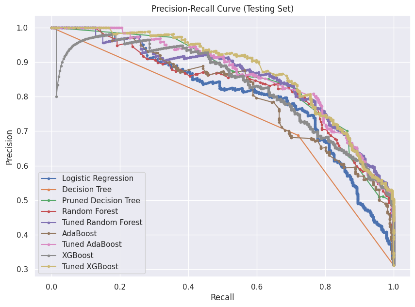

```python
# Plotting Precision-Recall curves for all models
plt.figure(figsize=(10, 7))

for model_name, results in model_results.items():
    # Get the predicted probabilities for the positive class (Converted)
    y_score = results['Testing Probabilities']

    # Calculate precision and recall for different probability thresholds
    precision, recall, _ = precision_recall_curve(y_test, y_score)

    # Plot the Precision-Recall curve
    plt.plot(recall, precision, marker='.', label=f'{model_name}')

plt.xlabel('Recall')
plt.ylabel('Precision')
plt.title('Precision-Recall Curve (Testing Set)')
plt.legend()
plt.grid(True)
plt.show()
```

##### **ROC Curves**

The ROC curve plots the True Positive Rate (Sensitivity) against the False Positive Rate (1-Specificity) at various threshold settings. The Area Under the Curve (AUC) provides a single metric summarising the model's ability to discriminate between the positive and negative classes across all possible thresholds.

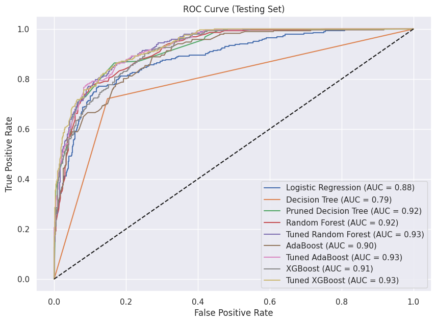

```python
# Plotting ROC curves for all models
plt.figure(figsize=(10, 7))

for model_name, results in model_results.items():
    # Get the predicted probabilities for the positive class (Converted)
    y_score = results['Testing Probabilities']

    # Calculate false positive rate (fpr) and true positive rate (tpr) for different probability thresholds
    fpr, tpr, _ = roc_curve(y_test, y_score)
    roc_auc = results['Testing ROC AUC']

    # Plot the ROC curve
    plt.plot(fpr, tpr, label=f'{model_name} (AUC = {roc_auc:.2f})')

plt.plot([0, 1], [0, 1], 'k--') # Plot the diagonal line for a random classifier
plt.xlabel('False Positive Rate')
plt.ylabel('True Positive Rate')
plt.title('ROC Curve (Testing Set)')
plt.legend()
plt.grid(True)
plt.show()
```

#### **Comparison of Confusion Matrices for Top Models**

To visually compare how the top-performing models perform in classifying converted and non-converted leads, we will display their confusion matrices side-by-side. This allows for a direct comparison of True Positives, True Negatives, False Positives, and False Negatives.

```
--- Confusion Matrices for Top 9 Models (Based on Test ROC AUC) ---
```

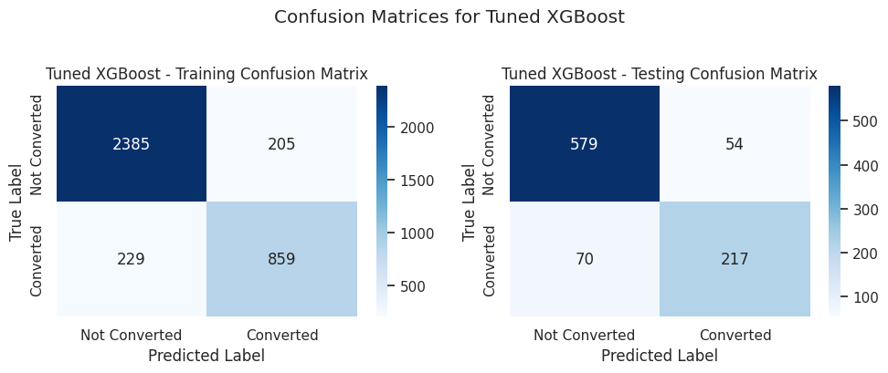

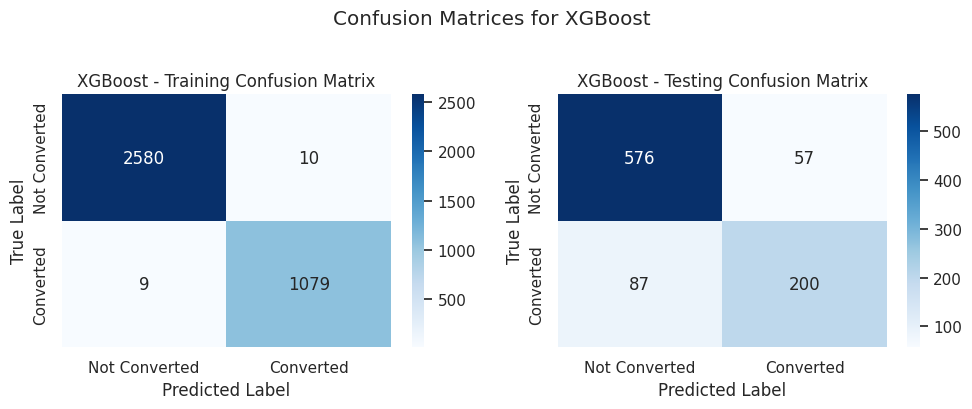

```python
# Get the names of the top models based on the sorted results_df_sorted
top_models = results_df_sorted.index.tolist()

# Plot confusion matrices for all models in the results dictionary
plot_top_n_confusion_matrices(model_results, results_df_sorted, len(top_models))
```

[output not shown]

#### **Training vs. Testing Performance Comparison**

To assess whether our models are overfitting or underfitting, we will visualize their performance metrics on both the training and testing sets. A significant gap between training and testing performance suggests overfitting, while poor performance on both suggests underfitting.

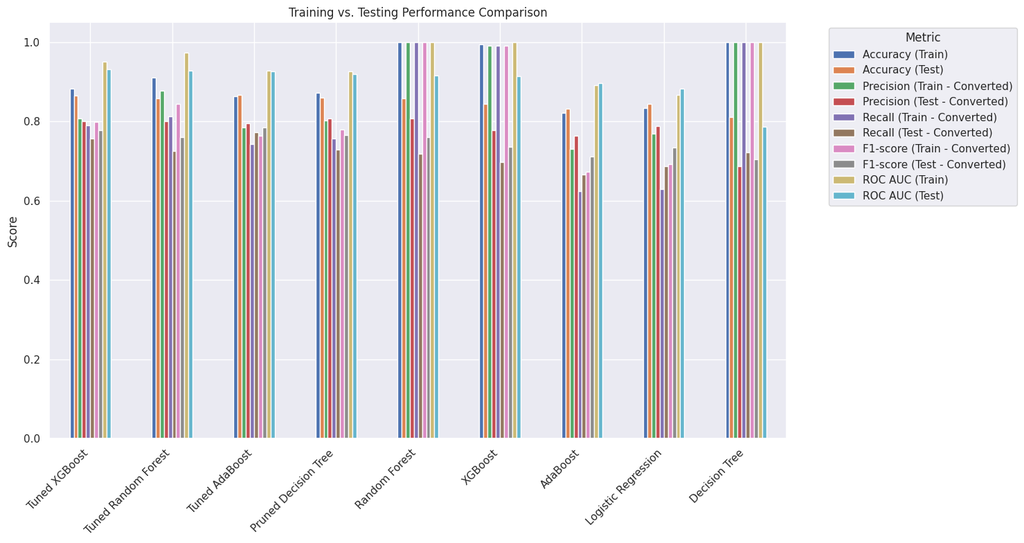

```python
# Select key performance metrics for visualization on both train and test sets
metrics_for_comparison = ['Accuracy (Train)', 'Accuracy (Test)',
                          'Precision (Train - Converted)', 'Precision (Test - Converted)',
                          'Recall (Train - Converted)', 'Recall (Test - Converted)',
                          'F1-score (Train - Converted)', 'F1-score (Test - Converted)',
                          'ROC AUC (Train)', 'ROC AUC (Test)']

# Create a bar plot to compare the models based on the selected metrics for both train and test sets
results_df_sorted[metrics_for_comparison].plot(kind='bar', figsize=(15, 8))

plt.title('Training vs. Testing Performance Comparison')
plt.ylabel('Score')
plt.xticks(rotation=45, ha='right')
plt.legend(title='Metric', bbox_to_anchor=(1.05, 1), loc='upper left')
plt.tight_layout()
plt.show()
```